# M4 Data Analysis: One Sample Procedures

Benjamin Panny

date()

```
## Loading objects:
##   cd4
```

# 1 CD4 cell counts

## 1.1 A description of the population and the sample

Our population of interest is HIV-infected patients prior to treatment. Our sample consists of 29 patients from this population.

## 1.2 A numerical and visual summary of the CD4 cell counts from the sample

```r
kableExtra::kable(summarize(cd4, n_NA = sum(is.na(cd4)), mean = mean(cd4, na.rm=TRUE), SD = sd(cd4, na.rm=TRUE),
              median = median(cd4, na.rm=TRUE),
              IQR = quantile(cd4, 0.75, na.rm=TRUE)-quantile(cd4, 0.25, na.rm=TRUE),
              min = min(cd4, na.rm=TRUE),
              max = max(cd4, na.rm=TRUE)), digits = 3, "simple", caption="CD4 Cell Counts from 29 HIV-infected Patients Prior to Treatment" )
```

CD4 Cell Counts from 29 HIV-infected Patients Prior to Treatment

| n_NA | mean | SD | median | IQR | min | max |
| --- | --- | --- | --- | --- | --- | --- |
| 0 | 188.103 | 42.128 | 194.627 | 61.509 | 104.234 | 269.378 |

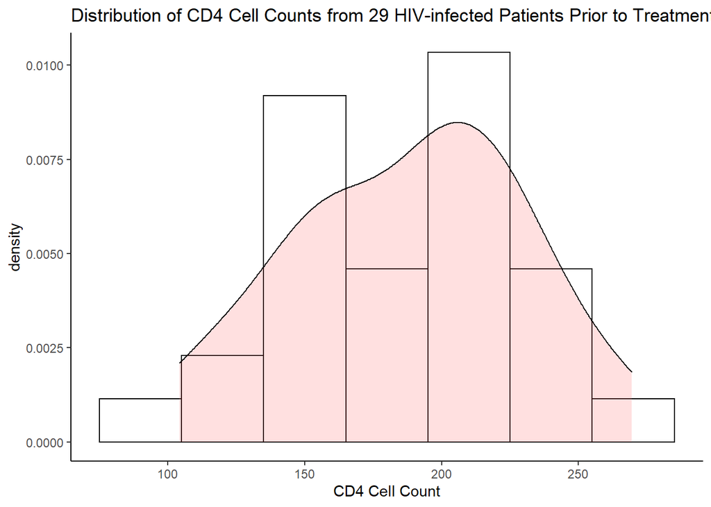

```r
ggplot(cd4, aes(x=cd4)) + geom_histogram(aes(y=..density..),binwidth = 30, color="black", fill="white") +
  geom_density(alpha=.2, fill="#FF6666") + theme_classic() + # use 10 count wide bins
  xlab("CD4 Cell Count") + # label the x-axis
  ggtitle("Distribution of CD4 Cell Counts from 29 HIV-infected Patients Prior to Treatment")  # title the plot
```

## 1.3 The null and alternative hypotheses

The null hypothesis is that the CD4 cell counts of HIV-infected patients prior to treatment is 200. The alternative hypothesis is that the average CD4 cell counts of HIV-infected patients prior to treatment is at less than 200.

## 1.4 Check the conditions for using the appropriate hypothesis test

*We will assume the sample of 29 HIV positive patients was randomly selected, making it a simple random sample.* Population average of CD4 cell counts of HIV-infected patients prior to treatment is normally distributed or n > 30. Sample size is less than 30 (n=29). We will assume the population is normally distributed because of [prior literature](https://www.ncbi.nlm.nih.gov/pmc/articles/PMC3162193/) in HIV negative patients showing a normal distribution of CD4 cell counts [Figure 1 from aforementioned prior literature](https://www.ncbi.nlm.nih.gov/core/lw/2.0/html/tileshop_pmc/tileshop_pmc_inline.html?title=Click%20on%20image%20to%20zoom&p=PMC3&id=3162193_TOAIDJ-5-74_F1.jpg). Even if this assumption based on HIV-negative patients is wrong, n=29 is still fairly close to 30, so there is enough reason to believe the t procedure for one mean is applicable. We also note that the sample is approximately normally distributed according to the below normal quantile plot.

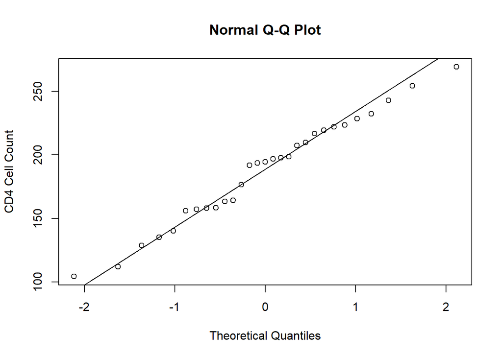

```r
qqnorm(cd4[, 1], ylab = "CD4 Cell Count")
qqline(cd4[, 1])
```

## 1.5 Identify and interpret the test statistic and p-value. (Hint: The test statistic measures…what? The p-value is the probability of…what?)

The t-statistic is -1.5208 and the p.value is 0.0698. This t-statistic indicates that the sample mean is 1.5208 sample-size adjusted standard deviations below the hypothesized value. The p-value means that the probability of observing the sample mean we observe or one even further from the hypothesized mean, given the observed standard deviation and sample size, is 0.0698 (6.98% chance) if the hypothesized value of 200 is truly the mean for this population.

```r
t.test(x = cd4, mu = 200, alternative = "less")
```

```
##
##  One Sample t-test
##
## data:  cd4
## t = -1.5208, df = 28, p-value = 0.06976
## alternative hypothesis: true mean is less than 200
## 95 percent confidence interval:
##      -Inf 201.4106
## sample estimates:
## mean of x
##  188.1027
```

```r
power.orig = power.t.test(n = 29, delta = (200 - mean(cd4[, 1])), sd = s, type = "one.sample", alternative = "one.sided")
power.orig[5]
```

```
## $power
## [1] 0.4360915
```

## 1.7 A confidence interval and interpretation of it in the context of the problem. Discuss if this agrees with the results of the hypothesis test.

```r
u.ci = x.bar + 1.7016 * s/(sqrt(n))
l.ci = x.bar - 1.7016 * s/(sqrt(n))

paste0("The 95% confidence interval for average cd4 cell counts is (", round(l.ci, digits = 2), ", ",
    round(u.ci, digits = 2), ")")
```

```
## [1] "The 95% confidence interval for average cd4 cell counts is (174.79, 201.41)"
```

## 1.8 The researchers are planning a follow-up study to this, to again examine whether the average CD4 cell counts of HIV-infected patients prior to treatment is less than 200. If they want to be able to detect a difference in the average cell count of 10 cells, find the necessary sample sizes for having statistical power of 0.50, 0.60, 0.70, 0.80, and 0.90.

The necessary sample sizes for having the given statistical powers while being able to detect a difference of 10 cells in the average cell count is given underneath the below code.

```r
p5 = power.t.test(power = 0.5, delta = 10, sd = s, type = "one.sample", alternative = "one.sided")

p6 = power.t.test(power = 0.6, delta = 10, sd = s, type = "one.sample", alternative = "one.sided")

p7 = power.t.test(power = 0.7, delta = 10, sd = s, type = "one.sample", alternative = "one.sided")

p8 = power.t.test(power = 0.8, delta = 10, sd = s, type = "one.sample", alternative = "one.sided")

p9 = power.t.test(power = 0.9, delta = 10, sd = s, type = "one.sample", alternative = "one.sided")

cat(paste0("The necessary sample size to detect a difference of 10 with 50% power is ", ceiling(as.numeric(p5[1])),
    "\n\nThe necessary sample size to detect a difference of 10 with 60% power is ", ceiling(as.numeric(p6[1])),
    "\n\nThe necessary sample size to detect a difference of 10 with 70% power is ", ceiling(as.numeric(p7[1])),
    "\n\nThe necessary sample size to detect a difference of 10 with 80% power is ", ceiling(as.numeric(p8[1])),
    "\n\nThe necessary sample size to detect a difference of 10 with 90% power is ", ceiling(as.numeric(p9[1]))))
```

```
## The necessary sample size to detect a difference of 10 with 50% power is 50
##
## The necessary sample size to detect a difference of 10 with 60% power is 66
##
## The necessary sample size to detect a difference of 10 with 70% power is 85
##
## The necessary sample size to detect a difference of 10 with 80% power is 112
##
## The necessary sample size to detect a difference of 10 with 90% power is 154
```

# 2 Lung cancer rate

## 2.1 A description of the population and the sample

The population of interest is the male chemical plant workers who die after working for the plant at least 1 year and the sample is the male chemical plant workers who died between 1970-1972 who had been working for the plant for at least 1 year.

## 2.2 The null and alternative hypotheses

The null hypothesis is that the proportion of deaths due to lung cancer in a population of males working at a chemical plant is the same as the proportion of deaths due to lung cancer in the general population. The alternative hypothesis is that the proportion of deaths due to lung cancer in a population of males working at a chemical plant is significantly greater than the proportion of deaths due to lung cancer in the general population.

## 2.3 Check the conditions for using the appropriate hypothesis test

We will first check the conditions for a Z procedure for one proportion because the simple random sample condition is met because our sample is, presumably, all of the deaths that occurred in plant workers from 1970-1972 who’ve worked for the plant at least one year. As such, it is the full population of deaths at this plant we are measuring, foregoing the simple random sample condition because the population fully represents itself. There is also no reason to assume that the selection of 1970-1972 is not representative of years prior and in the future, all other things being equal.

There are also close to five expected successes given the general (hypothesized) proportion. n x p0 = 40 x .12 = 4.8. However, the condition that the number of expected lung cancer deaths is at least 5 is not met.

Because one of the conditions for the Z procedure is not met, we can use the Exact Binomial test.

## 2.4 Identify and interpret the test statistic and p-value. (Hint: The test statistic measures…what? The p-value is the probability of…what?)

```r
pbinom(10, 40, 0.12, lower.tail = FALSE)
```

```
## [1] 0.006153352
```

## 2.5 A statistical decision (reject or fail to reject the null hypothesis) and conclusion in the context of the problem

We reject the null hypothesis, we have evidence that the population proportion of male worker deaths due to the lung cancer at the chemical plant is greater than the expected value given the population proportion of male worker deaths due to the lung cancer in the general population.

## 2.6 A confidence interval and interpretation of it in the context of the problem. Discuss if this agrees with the results of the hypothesis test.

```r
BinomCI(10, 40, conf.level = 0.9, method = "clopper-pearson")
```

```
##       est    lwr.ci    upr.ci
## [1,] 0.25 0.1423699 0.3870602
```